# Feature selection on titanic data using parallel coordinate plots

A parallel coordinate plot is ideal for comparing many variables together and seeing the relationship between them. Values are lotted as a series of lines that connected across all axes. This means that each line is a collection of points placed on each axis, that have all been colleccted together. To read more about parallel coordinate plots, you can click here.

The goal of this tutorial is to see how we can use parallel coordinate plots for feature selection in titanic data

The titanic dataset describes the survival status of individual passengers on the titanic

```python
%matplotlib inline

import pandas as pd
import numpy as np
from pandas import DataFrame
from pylab import *
import matplotlib.pyplot as plot
```

```python
titanic = pd.read_excel("titanic3.xls")
```

```python
titanic.head()
```

|  | pclass | survived | name | sex | age | sibsp | parch | ticket | fare | cabin | embarked | boat | body | home.dest |
| --- | --- | --- | --- | --- | --- | --- | --- | --- | --- | --- | --- | --- | --- | --- |
| 0 | 1 | 1 | Allen, Miss. Elisabeth Walton | female | 29.0000 | 0 | 0 | 24160 | 211.3375 | B5 | S | 2 | NaN | St Louis, MO |
| 1 | 1 | 1 | Allison, Master. Hudson Trevor | male | 0.9167 | 1 | 2 | 113781 | 151.5500 | C22 C26 | S | 11 | NaN | Montreal, PQ / Chesterville, ON |
| 2 | 1 | 0 | Allison, Miss. Helen Loraine | female | 2.0000 | 1 | 2 | 113781 | 151.5500 | C22 C26 | S | NaN | NaN | Montreal, PQ / Chesterville, ON |
| 3 | 1 | 0 | Allison, Mr. Hudson Joshua Creighton | male | 30.0000 | 1 | 2 | 113781 | 151.5500 | C22 C26 | S | NaN | 135.0 | Montreal, PQ / Chesterville, ON |
| 4 | 1 | 0 | Allison, Mrs. Hudson J C (Bessie Waldo Daniels) | female | 25.0000 | 1 | 2 | 113781 | 151.5500 | C22 C26 | S | NaN | NaN | Montreal, PQ / Chesterville, ON |

```python
titanic.shape
```

```
(1309, 14)
```

```python
summary = titanic.describe()
```

```python
summary
```

|  | pclass | survived | age | sibsp | parch | fare | body |
| --- | --- | --- | --- | --- | --- | --- | --- |
| count | 1309.000000 | 1309.000000 | 1046.000000 | 1309.000000 | 1309.000000 | 1308.000000 | 121.000000 |
| mean | 2.294882 | 0.381971 | 29.881135 | 0.498854 | 0.385027 | 33.295479 | 160.809917 |
| std | 0.837836 | 0.486055 | 14.413500 | 1.041658 | 0.865560 | 51.758668 | 97.696922 |
| min | 1.000000 | 0.000000 | 0.166700 | 0.000000 | 0.000000 | 0.000000 | 1.000000 |
| 25% | 2.000000 | 0.000000 | 21.000000 | 0.000000 | 0.000000 | 7.895800 | 72.000000 |
| 50% | 3.000000 | 0.000000 | 28.000000 | 0.000000 | 0.000000 | 14.454200 | 155.000000 |
| 75% | 3.000000 | 1.000000 | 39.000000 | 1.000000 | 0.000000 | 31.275000 | 256.000000 |
| max | 3.000000 | 1.000000 | 80.000000 | 8.000000 | 9.000000 | 512.329200 | 328.000000 |

lets slim down the dataset, because some of these features donnot help much in prediction. For this tutorial we shall remove name,ticket, cabin, boat, body and home.dest, just to keep things simple.

```python
titanic = titanic.drop(['name', 'ticket', 'cabin', 'boat', 'body', 'home.dest'], axis = 1)
```

```python
titanic.head()
```

|  | pclass | survived | sex | age | sibsp | parch | fare | embarked |
| --- | --- | --- | --- | --- | --- | --- | --- | --- |
| 0 | 1 | 1 | female | 29.0000 | 0 | 0 | 211.3375 | S |
| 1 | 1 | 1 | male | 0.9167 | 1 | 2 | 151.5500 | S |
| 2 | 1 | 0 | female | 2.0000 | 1 | 2 | 151.5500 | S |
| 3 | 1 | 0 | male | 30.0000 | 1 | 2 | 151.5500 | S |
| 4 | 1 | 0 | female | 25.0000 | 1 | 2 | 151.5500 | S |

lets drop rows with missing observations in the dataset

```python
titanic = titanic.dropna()
```

```python
titanic.shape
```

```
(1043, 8)
```

Creating dummy variables for sex and embarked

```python
pd.unique(titanic['sex'])
```

```
array(['female', 'male'], dtype=object)
```

```python
pd.unique(titanic['embarked'])
```

```
array(['S', 'C', 'Q'], dtype=object)
```

```python
Sex1 = []
Embarked = []
for i in range(titanic.shape[0]):
    if(titanic.iloc[i,2] == "male"):
        Sex1.append(0)
    else:
        Sex1.append(1)

for i in range(titanic.shape[0]):
    if(titanic.iloc[i,7] == 'S'):
        Embarked.append(0)
    elif(titanic.iloc[i,7] == 'C'):
        Embarked.append(1)
    else:
        Embarked.append(2)
```

```python
titanic['sex'] = Sex1
titanic['embarked'] = Embarked
```

```python
titanic.head()
```

|  | pclass | survived | sex | age | sibsp | parch | fare | embarked |
| --- | --- | --- | --- | --- | --- | --- | --- | --- |
| 0 | 1 | 1 | 1 | 29.0000 | 0 | 0 | 211.3375 | 0 |
| 1 | 1 | 1 | 0 | 0.9167 | 1 | 2 | 151.5500 | 0 |
| 2 | 1 | 0 | 1 | 2.0000 | 1 | 2 | 151.5500 | 0 |
| 3 | 1 | 0 | 0 | 30.0000 | 1 | 2 | 151.5500 | 0 |
| 4 | 1 | 0 | 1 | 25.0000 | 1 | 2 | 151.5500 | 0 |

Using a boxplot to visualize our data

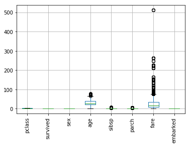

```python
titanic.boxplot(rot=90)
```

Some variables are not seen because of the difference in scale, the solution is to normalize the data a plot again

```python
from sklearn import preprocessing
```

```python
norm_titanic = preprocessing.normalize(titanic)
columnames = titanic.columns
norm_titanic = DataFrame(norm_titanic, columns= columnames)
```

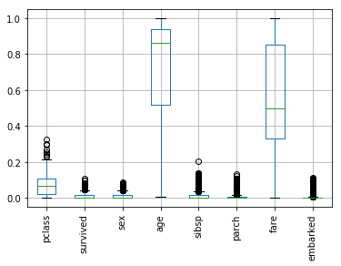

```python
norm_titanic.boxplot(rot=90)
```

```python
norm_titanic.head()
```

|  | pclass | survived | sex | age | sibsp | parch | fare | embarked |
| --- | --- | --- | --- | --- | --- | --- | --- | --- |
| 0 | 0.004688 | 0.004688 | 0.004688 | 0.135943 | 0.000000 | 0.000000 | 0.990683 | 0.0 |
| 1 | 0.006597 | 0.006597 | 0.000000 | 0.006048 | 0.006597 | 0.013195 | 0.999829 | 0.0 |
| 2 | 0.006597 | 0.000000 | 0.006597 | 0.013194 | 0.006597 | 0.013194 | 0.999761 | 0.0 |
| 3 | 0.006472 | 0.000000 | 0.000000 | 0.194162 | 0.006472 | 0.012944 | 0.980841 | 0.0 |
| 4 | 0.006510 | 0.000000 | 0.006510 | 0.162738 | 0.006510 | 0.013019 | 0.986519 | 0.0 |

```python
cols = list(norm_titanic.columns)
```

```python
new_col = [cols[1]]
new_col
```

```
['survived']
```

```python
new_col.extend([cols[0]])
new_col
```

```
['survived', 'pclass']
```

```python
new_col.extend(cols[2::])
new_col
```

```
['survived', 'pclass', 'sex', 'age', 'sibsp', 'parch', 'fare', 'embarked']
```

```python
norm_titanic = norm_titanic[new_col]
norm_titanic.head()
```

|  | survived | pclass | sex | age | sibsp | parch | fare | embarked |
| --- | --- | --- | --- | --- | --- | --- | --- | --- |
| 0 | 0.004688 | 0.004688 | 0.004688 | 0.135943 | 0.000000 | 0.000000 | 0.990683 | 0.0 |
| 1 | 0.006597 | 0.006597 | 0.000000 | 0.006048 | 0.006597 | 0.013195 | 0.999829 | 0.0 |
| 2 | 0.000000 | 0.006597 | 0.006597 | 0.013194 | 0.006597 | 0.013194 | 0.999761 | 0.0 |
| 3 | 0.000000 | 0.006472 | 0.000000 | 0.194162 | 0.006472 | 0.012944 | 0.980841 | 0.0 |
| 4 | 0.000000 | 0.006510 | 0.006510 | 0.162738 | 0.006510 | 0.013019 | 0.986519 | 0.0 |

Now that we have prepared our data we can now create our prallel coordinate plot

```python
plot.cm.RdYlBu(norm_titanic.iloc[i,1:7])
```

```
array([[0.83929258, 0.18454441, 0.15286428, 1.        ],
       [0.64705882, 0.        , 0.14901961, 1.        ],
       [0.22291426, 0.30865052, 0.6319877 , 1.        ],
       [0.64705882, 0.        , 0.14901961, 1.        ],
       [0.64705882, 0.        , 0.14901961, 1.        ],
       [0.97762399, 0.57739331, 0.33194925, 1.        ]])
```

```python
pd.plotting.parallel_coordinates(norm_titanic, 'fare', color = plot.cm.RdYlBu(norm_titanic.iloc[:,6]) , alpha = 0.3)
```

[figure not shown]

```python
new_col2 = new_col[1::]
new_col2
```

```
['pclass', 'sex', 'age', 'sibsp', 'parch', 'fare', 'embarked']
```

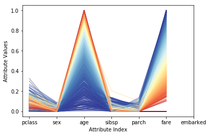

```python
for i in range(norm_titanic.shape[0]):
    #plot rows of data as if they were series data
    dataRow = norm_titanic.iloc[i,1:7]
    normTarget = norm_titanic.iloc[i,6]
    dataRow.plot(color=plot.cm.RdYlBu(normTarget), alpha=0.5)

plot.xticks(range(len(new_col2)),new_col2)
plot.xlabel("Attribute Index")
plot.ylabel(("Attribute Values"))
plot.show()
```

overlapping vs distinct colors which make good predictor for survival in titanic dataset As a rule of thumb, variables that have overlapping colors donnot make good predictors, in essence these are the variables we would drop from our feature set.

To prove this we can run a regression model and look at the probability values

```python
import statsmodels.formula.api as smf
```

```python
titanicModel = smf.ols(formula = 'survived ~ pclass + sex + age + sibsp + parch + fare + embarked', data = norm_titanic)
results = titanicModel.fit()
print(results.summary())
```

```
                            OLS Regression Results
==============================================================================
Dep. Variable:               survived   R-squared:                       0.312
Model:                            OLS   Adj. R-squared:                  0.307
Method:                 Least Squares   F-statistic:                     66.99
Date:                Sun, 28 Jul 2019   Prob (F-statistic):           1.06e-79
Time:                        12:36:26   Log-Likelihood:                 2972.3
No. Observations:                1043   AIC:                            -5929.
Df Residuals:                    1035   BIC:                            -5889.
Df Model:                           7
Covariance Type:            nonrobust
==============================================================================
                 coef    std err          t      P>|t|      [0.025      0.975]
------------------------------------------------------------------------------
Intercept     -0.0032      0.006     -0.537      0.592      -0.015       0.009
pclass         0.0862      0.011      7.664      0.000       0.064       0.108
sex            0.3772      0.030     12.591      0.000       0.318       0.436
age           -0.0021      0.005     -0.463      0.643      -0.011       0.007
sibsp         -0.1131      0.019     -5.895      0.000      -0.151      -0.075
parch          0.0933      0.024      3.808      0.000       0.045       0.141
fare           0.0101      0.005      2.064      0.039       0.000       0.020
embarked       0.0432      0.025      1.761      0.079      -0.005       0.091
==============================================================================
Omnibus:                      117.289   Durbin-Watson:                   1.769
Prob(Omnibus):                  0.000   Jarque-Bera (JB):              329.944
Skew:                           0.581   Prob(JB):                     2.26e-72
Kurtosis:                       5.498   Cond. No.                         97.9
==============================================================================

Warnings:
[1] Standard Errors assume that the covariance matrix of the errors is correctly specified.
```